# Introduction to GitHub

Mark Scheuerell

13 January 2027

# What is GitHub?

GitHub is a code hosting platform for version control and collaboration. It lets you and others work together on projects from anywhere. GitHub itself is not a development tool, but rather a file hosting and collaboration site. In many ways, a social network like Facebook. You can build a profile, create projects to share with others, and follow the accounts of other users. GitHub is not linked to any one programming language like **R**, as you can find all kinds of projects based upon different languages there.

GitHub also runs **Git** in the background. Git is a version control software, which means it records changes to a file or set of files over time so that you can recall specific versions later. We’ll learn more about Git in the next session.

You will need a GitHub account before you can start using it. If you do not have an account already, please see the info here for creating one.

# Repositories

A repository (or “repo” for short) is a directory or storage space for your projects on GitHub. Repositories can contain folders and files, images, videos, spreadsheets, and data sets. Most repos include a **`README.md`** file, which contains information about your project. GitHub makes it easy to add one at the same time you create your new repository. It also offers other common options such as a license file.

# Create a repository

1. Log into your account on GitHub.
2. Click on the **+** sign in the upper right and select **New repository**.

[figure not shown]

Name your new repository **testing**.

Repo names can also use underscores `_` and hypens `-` as text delimiters, if you’d like.

[figure not shown]

Enter some simple descriptive text in the **Description** field.

This can be changed later, so don’t worry about its content.

[figure not shown]

GitHub repos can be set to **Public** or **Private**. If set to public, anyone can browse the contents of your repo. If set to private, only you and those you specify as collaborators can view the contents of the repo.

Go ahead and set it to the default **Public**.

[figure not shown]

When you create a repo, you have the option of initializing it with a `README.md` file, a `.gitignore` file, and a license.

For now, just check the box next to **Add a README file**.

[figure not shown]

When you are finished, click on the green **Create repository** button.

[figure not shown]

You now have a new repo that is ready to be populated with folders, code, data sets, etc.

[figure not shown]

# Markdown

Markdown is a simple markup language for creating formatted text using a plain-text editor. It makes use of some special characters for formatting headers and text. GitHub automatically recognizes Markdown files with a `.md` extension and renders them as formatted information. The repo we just created has one file in it: `README.md`, and its contents are displayed at the bottom of the repo.

## Writing text

The text in a Markdown document can be formatting in a number of ways. At a basic level, it’s just various forms of text that are converted to nicely formatted features when the file is rendered.

### Headings

You can specify different levels of headings using the hash tag (pound) symbol `#`. By adding more `#` signs you can decrease the heading level. So, for example, the following

```
# Level-1 header
## Level-2 header
### Level-3 header
#### Level-4 header
```

will render to

Level-1 header

Level-2 header

Level-3 header

Level-4 header

### Emphasis

#### Italics

It’s easy to add emphasis to text. For *italic* face, wrap the text with either a single asterisk (`*`) or a single underscore (`_`). For example,

```
This is *italic*, but then so is _this_.
```

will result in

This is *italic*, but then so is *this*.

#### Bold

For **bold** face, wrap the text with either two asterisks (`**`) or two underscores (`__`). For example,

```
This is **bold**, but then so is __this__.
```

will render to

This is **bold**, but then so is **this**.

#### Bold & italic

For combined *bold and italics* face, wrap the text with three asterisks (`***`), such that

```
This is ***bold and italic***.
```

renders to

This is *bold and italic*.

#### Strike-through

If you want to indicate a deletion or strike-through, just wrap the text in two tilde’s (`~~`), such that

```
Oops, ~~this is a mistake~~.
```

will render to

Oops, this is a mistake.

### Block quotes

You can specify a block quote by preceding it with the `>` symbol, such that

```
> I have a dream that one day this nation will rise up and live out the true meaning of its creed: 'We hold these truths to be self-evident, that all men are created equal.'
```

yields

> I have a dream that one day this nation will rise up and live out the true meaning of its creed: ‘We hold these truths to be self-evident, that all men are created equal.’

### Lists

You can include ordered (numbered) lists, unordered (bulleted) lists, or a combination of the two in Markdown documents as well. Numbered lists simply use a number and period (`1.`) followed by a space and the text. For example, this text

```
1. This is item 1
2. Item 2 comes next
```

will render to

1. This is item 1
2. Item 2 comes next

It turns out that you don’t even have to use consecutive numbers to make it work. For example,

```
1. This is item 1
7. Item 2 comes next
```

will render to

1. This is item 1
2. Item 2 comes next

You can specify an unordered list with either an asterisk (`*`) or dash (`-`). For example, the following text

```
* This is a thing
* Here is another
- And yet another
```

will render to

- This is a thing
- Here is another
- And yet another

Mixed lists simply use a mixture of the two constructs, such that

```
1. This is item 1
   * This is a thing
   * Here is another
2. Item 2 comes next
   - And yet another
```

will render to

1. This is item 1
- This is a thing
- Here is another
2. Item 2 comes next
- And yet another

### Links

You can insert links to websites, other files, and other locations within a file. For websites, there are several options. The first is to simply write out the full address inline (eg, http://www.google.com) and it will parse correctly. You can also use shorthand text to hide the full address or make a sentence more readable. To do that, include the name in square brackets followed by the address inside parentheses. For example,

```
Please conduct your search using [this link](http://www.google.com).
```

will render as

Please conduct your search using [this link](http://www.google.com).

### Inserting pictures

#### Inline

Inserting links to images works much the same as for websites, but you add an exclamation point (`!`) at the beginning of the construct (and the text inside the square brackets in optional). For example, here is how to include the hex logo for this class.

```
![](hexsticker.png)
```

which will yield this

[figure not shown]

You can adjust the size of the image by specifying the height and width in percentages within curly brackets. For example,

```
![](hexsticker.png){ height=30% width=30% }
```

will yield this

[figure not shown]

## Displaying R code

One of the truly great features of Markdown is the ability to include code within a document. This course uses **R**, but people also use many other languages in Markdown documents (eg, Python).

### Blocks

The most common method for including code in your document is via code blocks, which can be numerous and separated by text, images, etc. Code blocks are delimited at the beginning and end by three back-ticks (```). So, for example, here is a really basic code block

````
```
a <- 1
b <- 2
```
````

that would look like

```r
a <- 1
b <- 2
```

Later in the course when we start using **R Markdown**, you’ll see that you can execute the code within a document and display the results.

### Inline

You can also include code snippets directly within text by surrounding it with single backticks (`). For example,

```
I assigned the the temporary data frame to the variable `tmp`.
```

will result in

I assigned the the temporary data frame to the variable `tmp`.

# Edit the README

You can treat the `README.md` file as a “landing page” for your repo. Because it’s a Markdown document, you can display images, lists, emphasis, etc. Similarly, you could add another `README.md` file inside a folder within a repo to describe the contents of the folder.

Edit your `README.md` file by clicking on the pencil icon in the upper right.

[figure not shown]

This brings up an editing window where you can add or modify existing text using the various formatting options via Markdown. Below you can see where I’ve added some Markdown flavored text.

Add some Markdown to your `README.md` file.

[figure not shown]

You can preview a formatted version of your text by clicking the **Preview** tab.

[figure not shown]

When you are done editing the text, you need to “commit” the changes. To do so, scroll down to the bottom of the page to the box marked **Commit changes**.

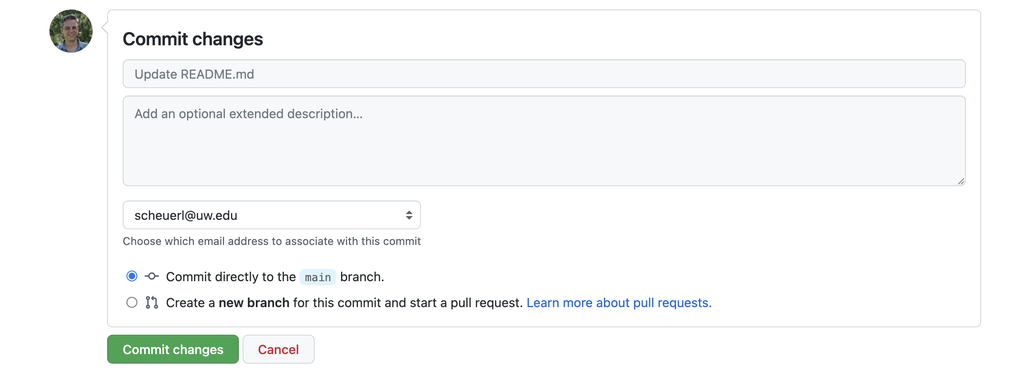

This is your first introduction to **Git**. When committing a file, you need to include a “short but informative” commit message to describe the changes you’ve made.

Go ahead and type a commit message in the box and then click the green **Commit changes** button.

Good commit messages are no more than 50 characters long. (Mark likes to begin his with a past-tense verb.)

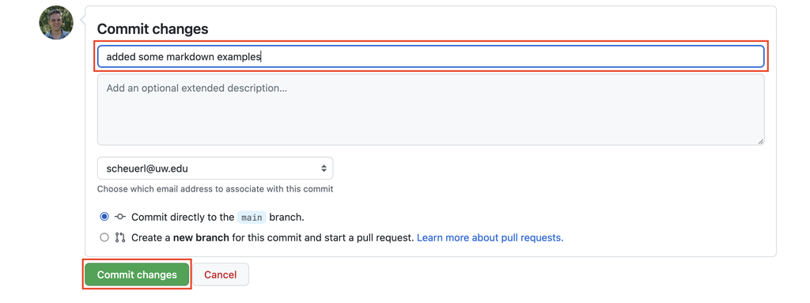

Your repo has a newly formatted `README.md` file.

[figure not shown]

# Issues

Issues are used to track to-do items, bugs, feature requests, and more. Some people will refer to these as “tickets” or “cards”. Let’s see how to add an issue to a repo.

Click on the **Issues** tab in the upper left near the **Code** tab that you are on now.

[figure not shown]

At this point the **Issues** page is empty except for a message from GitHub telling you a bit about Issues.

[figure not shown]

Click on the green **New issue** button in the upper right.

[figure not shown]

Now you will see a window for you to enter details about the issue.

[figure not shown]

Give your issue an informative title.

[figure not shown]

It’s common to include some details concerning an issue. For example, you might describe a problem you’re having or a bug you’ve encountered that will need to be fixed later. The issue description can also contain formatted text via the same Markdown we used on our `README.md` file. Below you can see where I’ve added some details about this issue.

Add some details in the description box.

- You can also make use of the tool bar to help you with formatting, inserting links, etc.
- You can create checkboxes in Markdown with `* [ ]`.

[figure not shown]

Just like we did when editing the `README.md` file, you can preview the formatted Markdown in an issue’s description by clicking on the **Preview** tab.

[figure not shown]

There are some additional options on the righthand side for assigning collaborators to work on an issue, assigning descriptive labels to the issue to help identify its contents, priority, etc. Notably, these labels are also searchable from the main **Issues** page.

[figure not shown]

Click on the **Assignees** link and then click on your username to select yourself.

[figure not shown]

Click on the **Labels** link to see a list of preset labels.

[figure not shown]

In this case I’ve added the following labels to the issue:

- **documentation**
- **enhancement**
- **good first issue**

[figure not shown]

When you are finished adding a description, labels, etc, click on the green **Submit new issue** button at the bottom.

[figure not shown]

You will now see your new issue as a formatted Markdown document with lots of information about it being “Open”, the labels you added, and another comment box at the bottom.

The checkboxes we added are dynamic and can be checked as tasks are completed.

[figure not shown]

Click on the **Issues** tab in the upper left, which will bring you back to the main **Issue** page.

[figure not shown]

There are a few things to note here:

- there is now a number “1” inside a circle next to the Issues tab, which means there is one open issue at the moment
- you can filter issues by clicking on the **Filters** dropdown menu on the left side
- you can use the search bar to the right of the **Filters** dropdown menu to find specific words or topics
- when there are multiple open issues, you can sort by **Author**, **Label**, etc by clicking on the column heading
- you can see there are 3 tasks within this issue below the issue’s title

From here you can add more issues, or click on an existing issue to bring up its details.